# Br 8325 basic analysis

Sowmya

8/26/2021

### plot spots

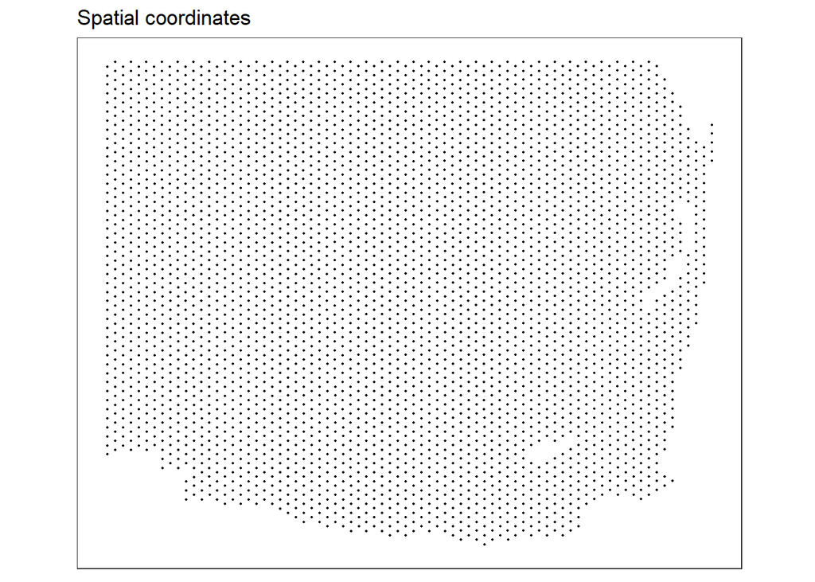

```r
plotSpots(spe,
  x_coord = "pxl_row_in_fullres",
  y_coord = "pxl_col_in_fullres")
```

## Quality Control

Low-quality spots can be identified according to several characteristics, including:

1. library size (i.e. total UMI counts per spot)
2. number of expressed features (i.e. number of genes with non-zero UMI counts per spot)
3. proportion of reads mapping to mitochondrial genes (a high proportion indicates cell damage)
4. number of cells per spot (unusually high values can indicate problems)

### keep only spots over tissue

```
## [1] 36601  3730
```

### identify mitochondrial genes

```
## is_mito
## FALSE  TRUE
## 36588    13
```

### list MT genes

```
##  [1] "MT-ND1"  "MT-ND2"  "MT-CO1"  "MT-CO2"  "MT-ATP8" "MT-ATP6" "MT-CO3"
##  [8] "MT-ND3"  "MT-ND4L" "MT-ND4"  "MT-ND5"  "MT-ND6"  "MT-CYB"
```

### Calculate per-spot QC metrics and store in colData

### library size histogram

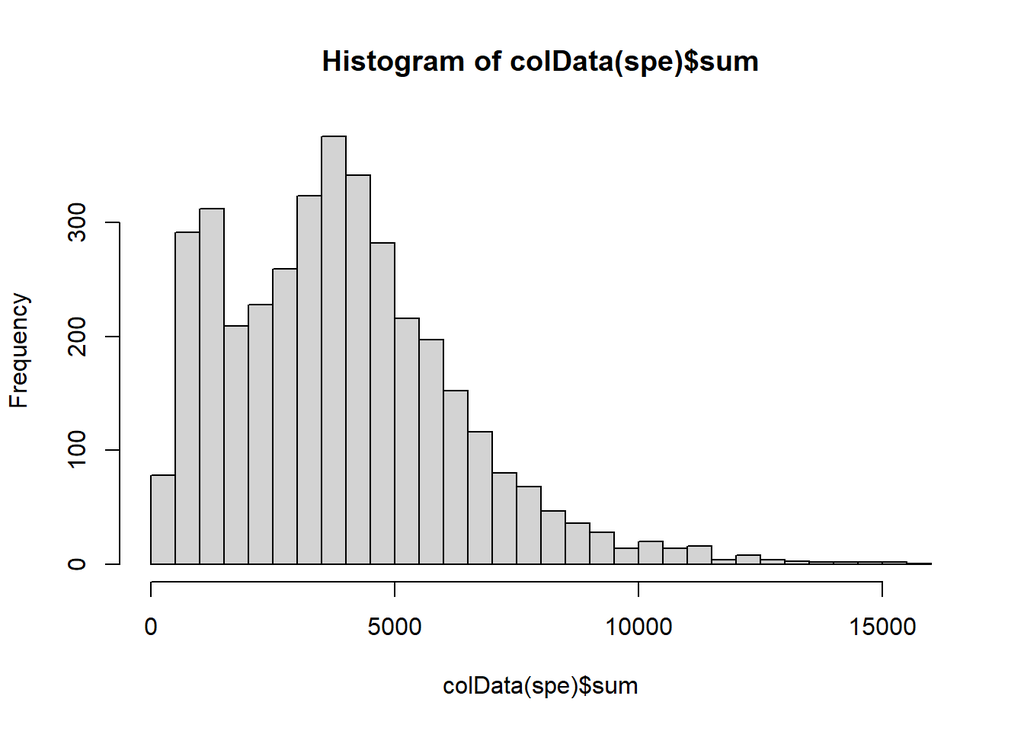

Spike at low library size?

### plot cell counts

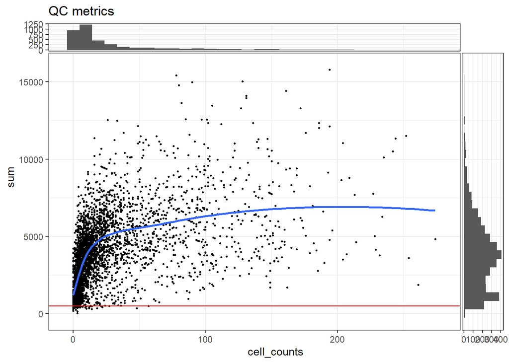

### spatial pattern of discarded spots for high threshold

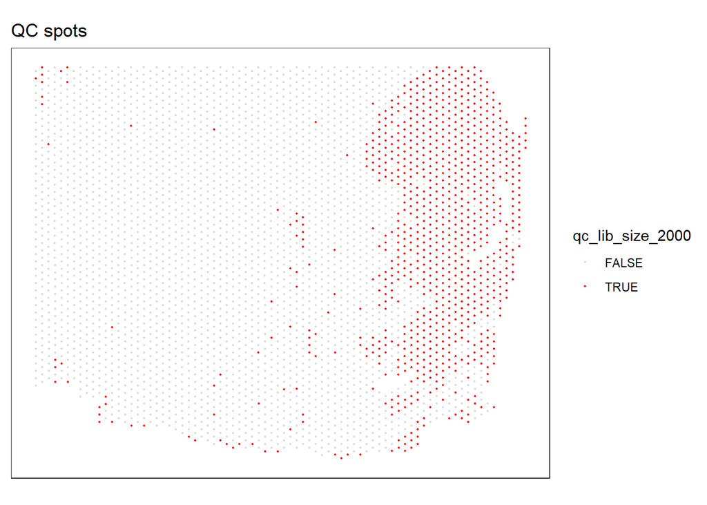

```r
qc_lib_size_2000 <- colData(spe)$sum < 2000
colData(spe)$qc_lib_size_2000 <- qc_lib_size_2000

plotQC(spe, type = "spots",
       x_coord = "pxl_row_in_fullres",
       y_coord = "pxl_col_in_fullres",
       discard = "qc_lib_size_2000")
```

###expressed genes

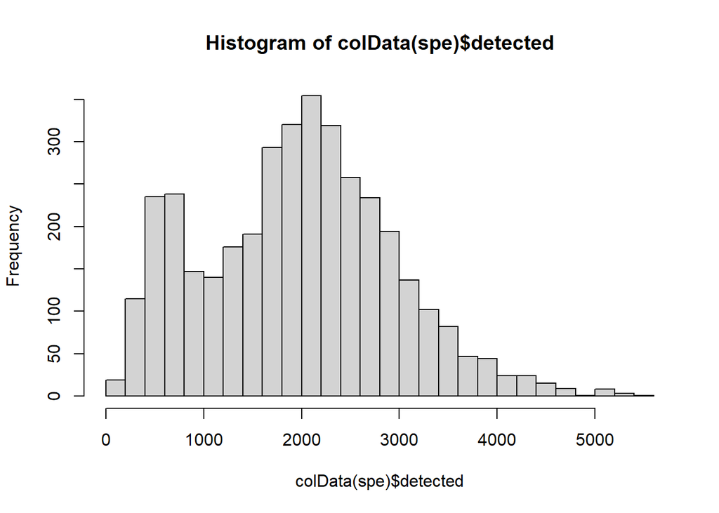

```r
#histogram of numbers of expressed genes
hist(colData(spe)$detected, breaks = 20)
```

### num expressed genes vs. num cells per spot

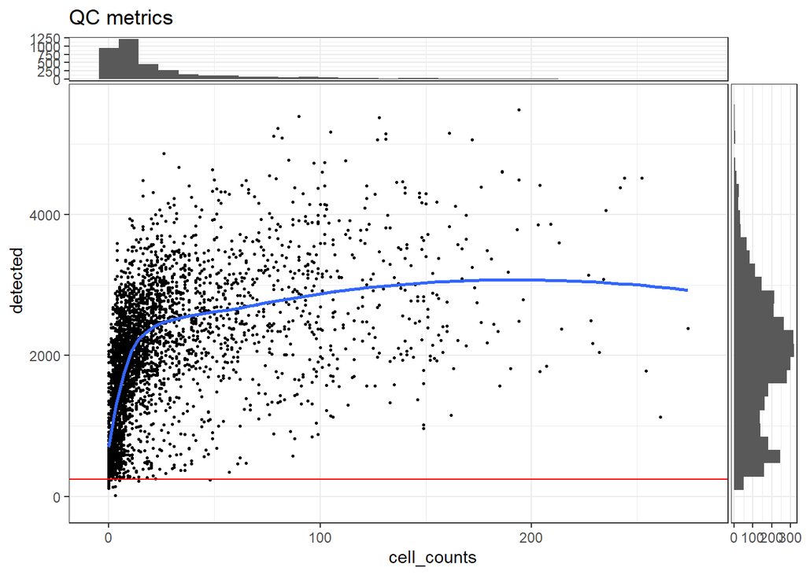

```r
plotQC(spe, type = "scatter",
       metric_x = "cell_counts", metric_y = "detected",
       threshold_y = 250)
```

### threshold for expressed genes

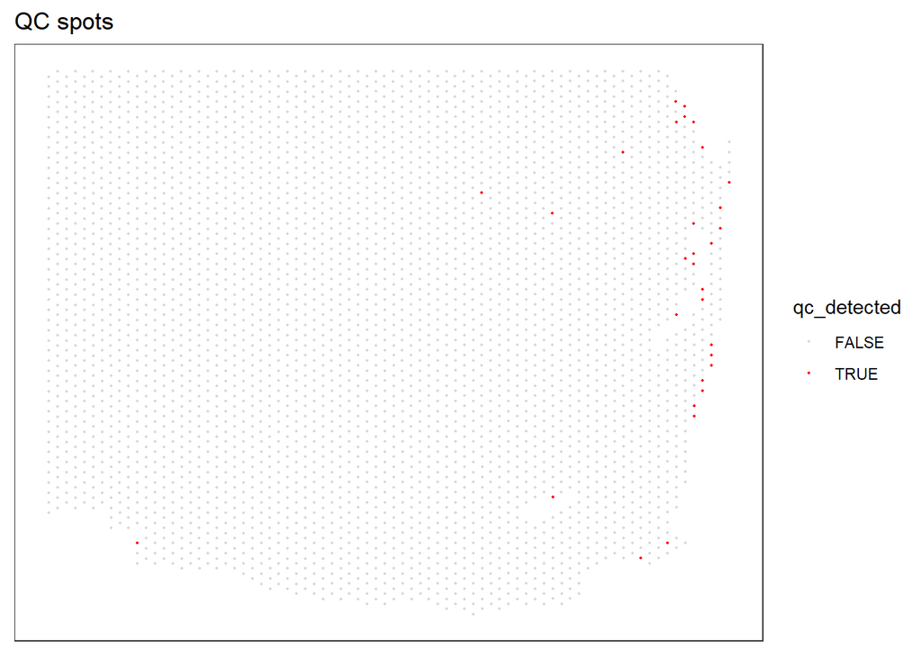

```r
qc_detected <- colData(spe)$detected < 250

colData(spe)$qc_detected <- qc_detected

plotQC(spe, type = "spots",
       x_coord = "pxl_row_in_fullres",
       y_coord = "pxl_col_in_fullres",
       discard = "qc_detected")
```

### check spatial pattern for high threshold

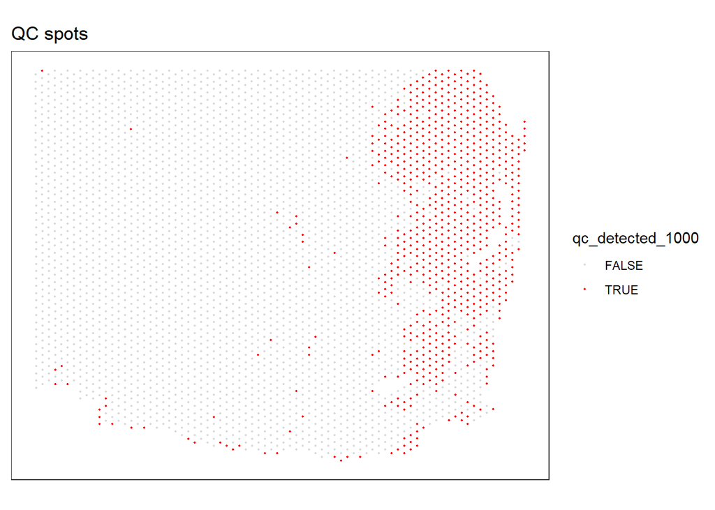

```r
qc_detected_1000 <- colData(spe)$detected < 1000
colData(spe)$qc_detected_1000 <- qc_detected_1000
plotQC(spe, type = "spots",
       x_coord = "pxl_row_in_fullres",
       y_coord = "pxl_col_in_fullres",
       discard = "qc_detected_1000")
```

## proportion of mitochondrial reads

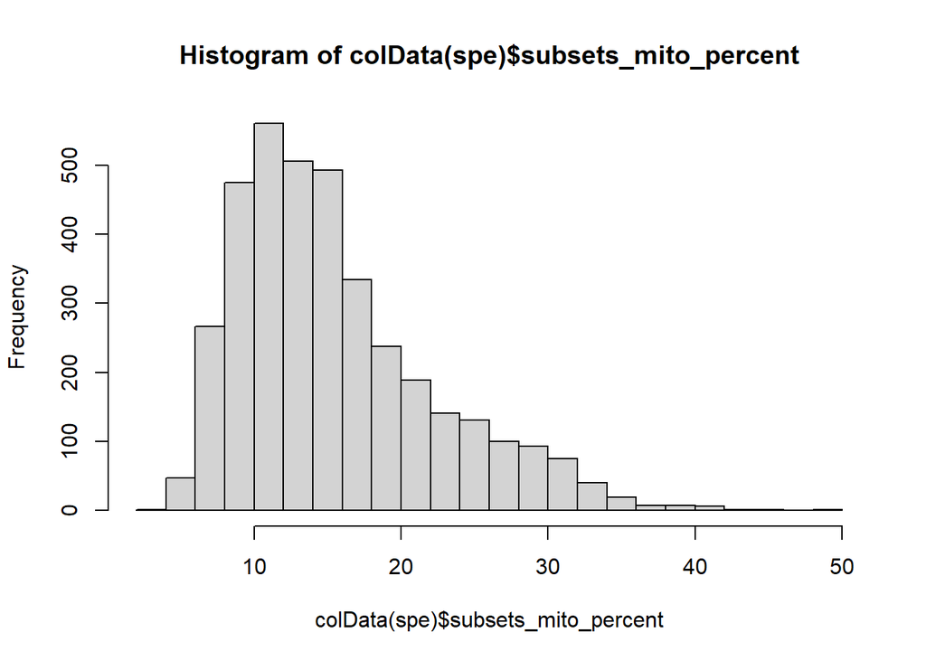

```r
hist(colData(spe)$subsets_mito_percent, breaks = 20)
```

### mito proportion vs. num cells per spot

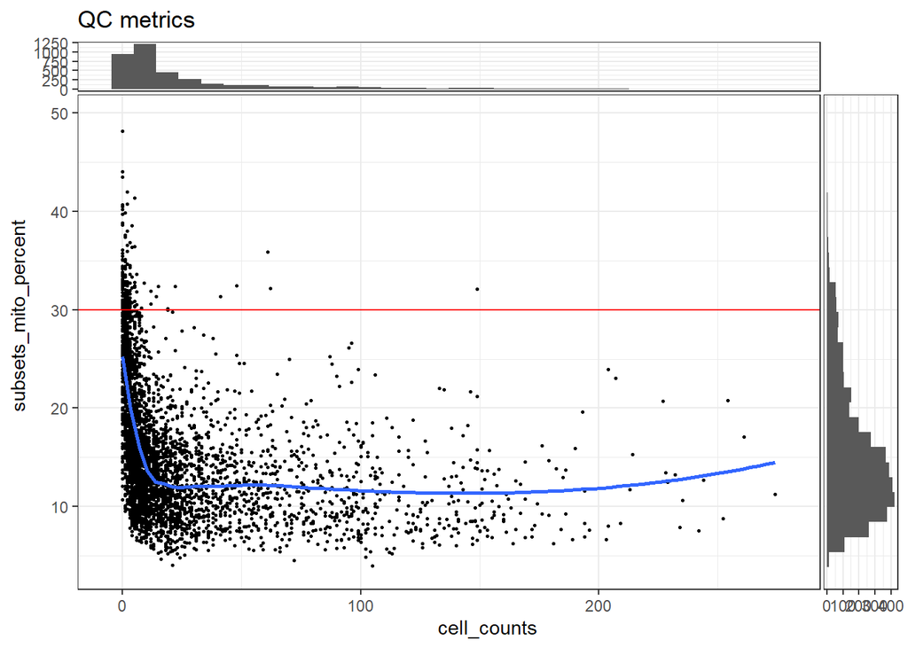

```r
plotQC(spe, type = "scatter",
       x_coord = "pxl_row_in_fullres",
       y_coord = "pxl_col_in_fullres",
       metric_x = "cell_counts", metric_y = "subsets_mito_percent",
       threshold_y = 30)
```

### mito thresholding @ 30

```r
qc_mito <- colData(spe)$subsets_mito_percent > 30
table(qc_mito)
```

```
## qc_mito
## FALSE  TRUE
##  3573   157
```

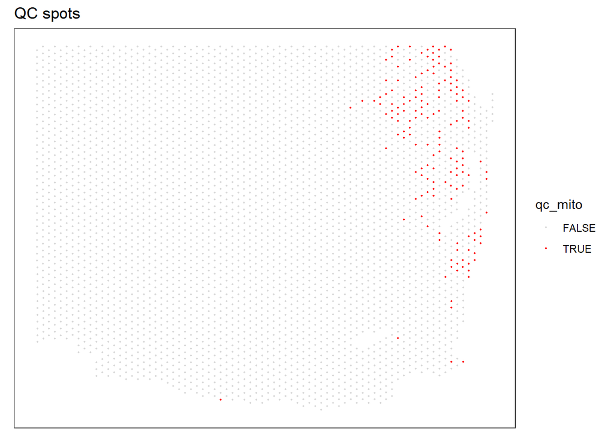

```r
colData(spe)$qc_mito <- qc_mito

plotQC(spe, type = "spots",
       x_coord = "pxl_row_in_fullres",
       y_coord = "pxl_col_in_fullres",
       discard = "qc_mito")
```

### cell counts histogram

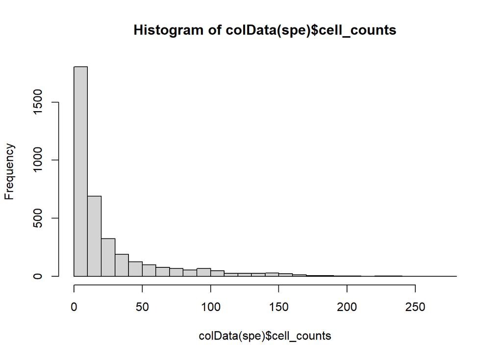

```r
hist(colData(spe)$cell_counts, breaks = 20)
```

### r distribution of cells per spot

```r
tbl_cells_per_spot <- table(colData(spe)$cell_count)
```

### num expressed genes vs. thresholded num cells

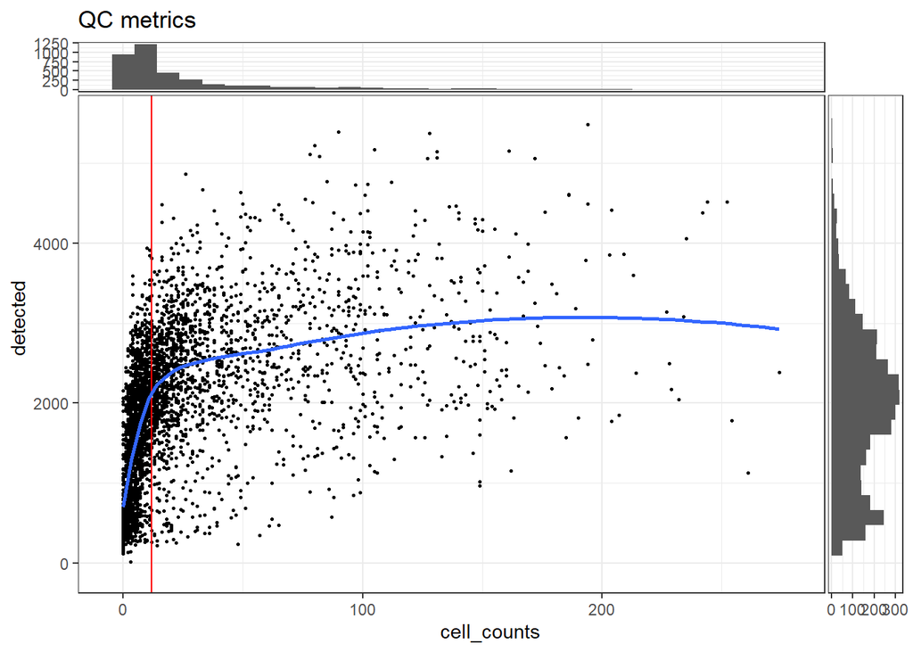

```r
plotQC(spe, type = "scatter",
       metric_x = "cell_counts", metric_y = "detected",
       threshold_x = 12)
```

From 9.5.4:

spots with very high cell counts also have low numbers of expressed genes. This indicates that the experiments have failed for these spots, and they should be removed.

Is 12 still a good threshold?

### selected QC threshold for number of cells per spot

```r
qc_cell_count <- colData(spe)$cell_counts > 12
table(qc_cell_count)
```

```
## qc_cell_count
## FALSE  TRUE
##  1991  1739
```

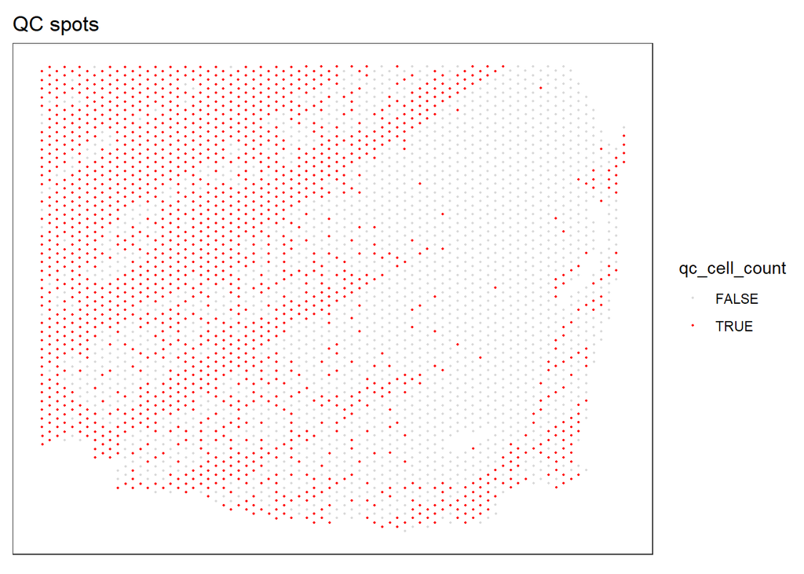

```r
colData(spe)$qc_cell_count <- qc_cell_count

# check spatial pattern of discarded spots
plotQC(spe, type = "spots",
       x_coord = "pxl_row_in_fullres",
       y_coord = "pxl_col_in_fullres",
       discard = "qc_cell_count")
```

Number of cells correlated with wrinkles. But is the other part of the tissue damaged? High mito count?

Should I be discarding anything at all?

## Normalization Chapter 10

Cluster similar cells based on their expression profiles, using either log-expression values or ranks.

```r
library(scran)
set.seed(123)
qclus <- quickCluster(spe)
table(qclus)
```

```
## qclus
##   1   2   3   4   5   6   7   8   9  10
## 434 132 525 625 316 429 258 349 291 371
```

### store size factors in objects

```r
# calculate size factors and store in object
spe <- computeSumFactors(spe, cluster = qclus)

summary(sizeFactors(spe))
```

```
##     Min.  1st Qu.   Median     Mean  3rd Qu.     Max.
## 0.002328 0.498457 0.935601 1.000000 1.355821 4.609540
```

### size factor hist

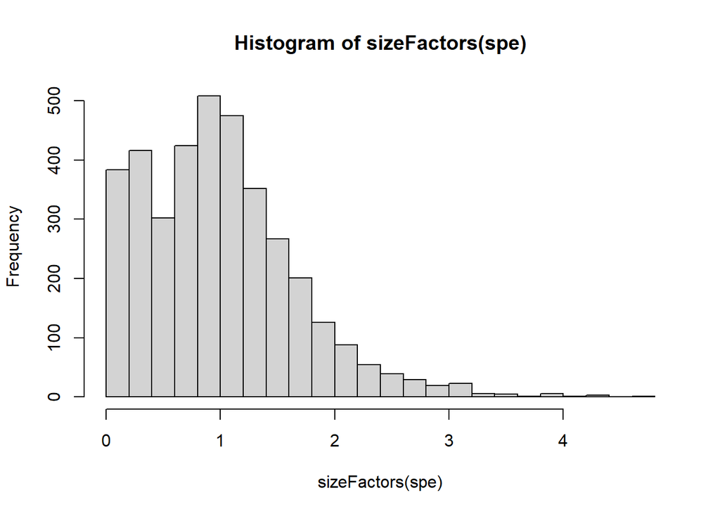

```r
hist(sizeFactors(spe), breaks = 20)
```

### calculate logcounts (log-transformed normalized counts)

```r
spe <- logNormCounts(spe)

# check
assayNames(spe)
```

```
## [1] "counts"    "logcounts"
```

## Feature selection and Dimensionality reduction

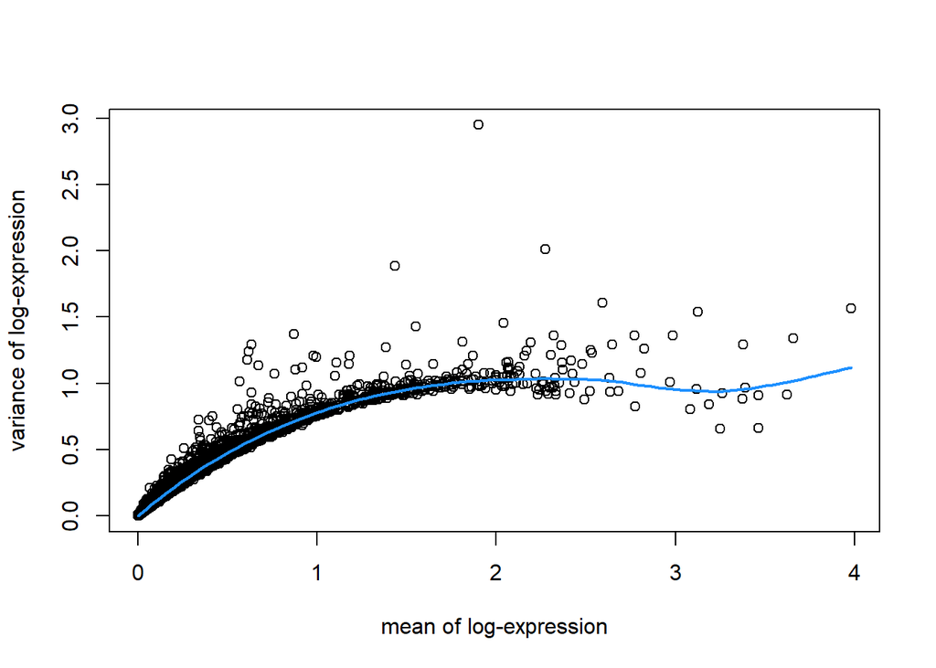

```r
library(scran)
# remove mitochondrial genes
spe <- spe[!is_mito, ]
# fit mean-variance relationship
dec <- modelGeneVar(spe)
# select top HVGs
top_hvgs <- getTopHVGs(dec, prop = 0.1)

# visualize mean-variance relationship
fit <- metadata(dec)
plot(fit$mean, fit$var,
     xlab = "mean of log-expression", ylab = "variance of log-expression")
curve(fit$trend(x), col = "dodgerblue", add = TRUE, lwd = 2)
```

Apply principal component analysis (PCA) to the set of top highly variable genes (HVGs) to reduce the dimensionality of the dataset, and retain the top 50 principal components (PCs) for further downstream analyses.

### compute PCA

```r
set.seed(123)
spe <- runPCA(spe, subset_row = top_hvgs)

reducedDimNames(spe)
```

```
## [1] "PCA"
```

```r
dim(reducedDim(spe, "PCA"))
```

```
## [1] 3730   50
```

### UMAP

```r
library(uwot)
set.seed(123)
spe <- runUMAP(spe, dimred = "PCA")
```

```
## Found more than one class "dist" in cache; using the first, from namespace 'BiocGenerics'
```

```
## Also defined by 'spam'
```

```
## Found more than one class "dist" in cache; using the first, from namespace 'BiocGenerics'
```

```
## Also defined by 'spam'
```

```r
reducedDimNames(spe)
```

```
## [1] "PCA"  "UMAP"
```

```r
dim(reducedDim(spe, "UMAP"))
```

```
## [1] 3730    2
```

```r
colnames(reducedDim(spe, "UMAP")) <- paste0("UMAP", 1:2)
```

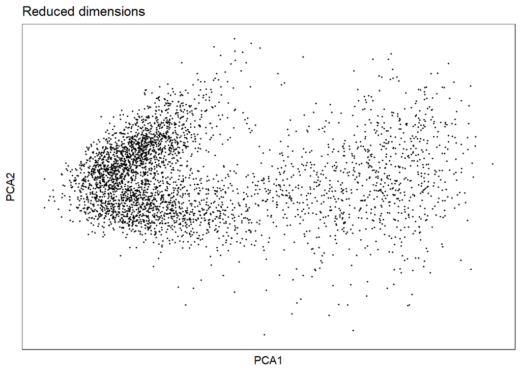

```r
plotDimRed(spe, type = "PCA")
```

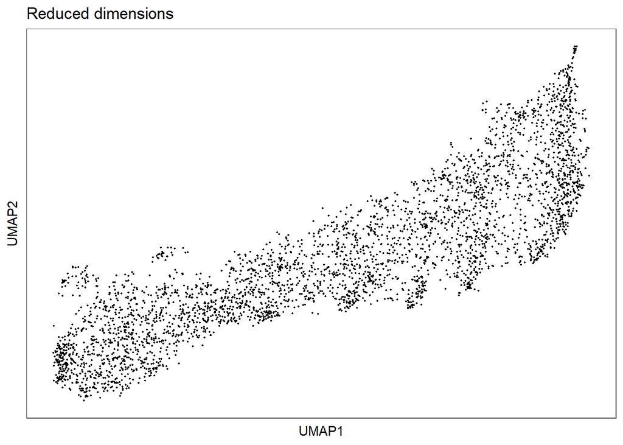

```r
plotDimRed(spe, type = "UMAP")
```

##Clustering

```r
# graph-based clustering
set.seed(123)
k <- 10
g <- buildSNNGraph(spe, k = k, use.dimred = "PCA")
g_walk <- igraph::cluster_walktrap(g)
clus <- g_walk$membership
table(clus)
```

```
## clus
##    1    2    3    4
## 1180  874  759  917
```

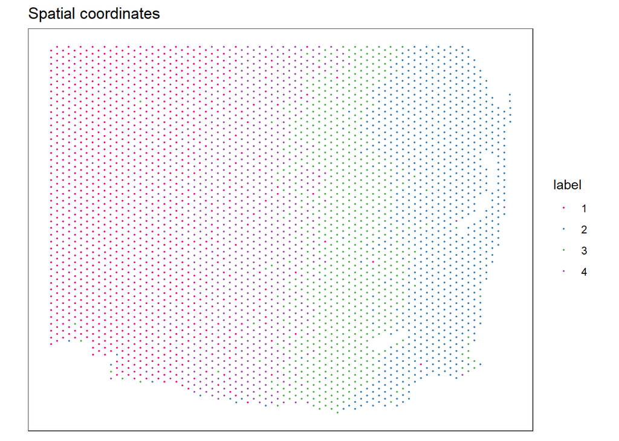

```r
# store cluster labels in column 'label' in colData
colLabels(spe) <- factor(clus)

plotSpots(spe, annotate = "label",
          x_coord = "pxl_row_in_fullres",
          y_coord = "pxl_col_in_fullres",
          palette = "libd_layer_colors")
```

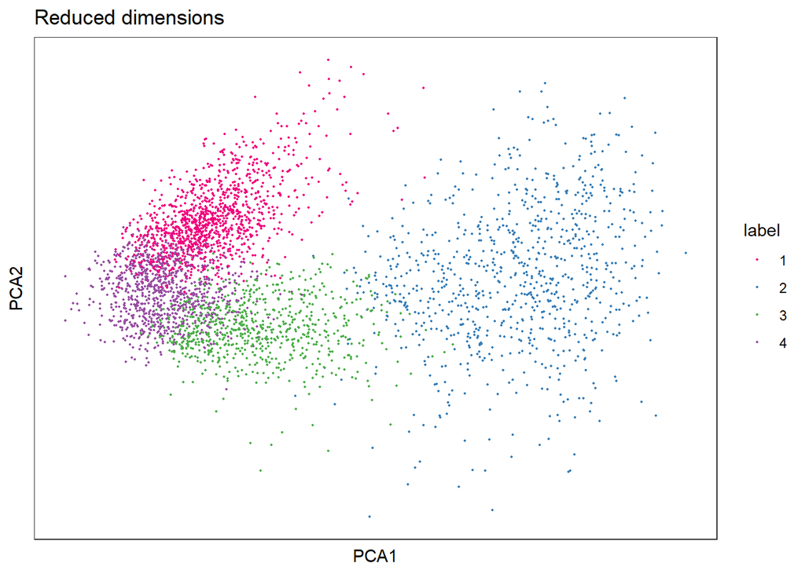

```r
# plot clusters in PCA reduced dimensions
plotDimRed(spe, type = "PCA",
           annotate = "label", palette = "libd_layer_colors")
```

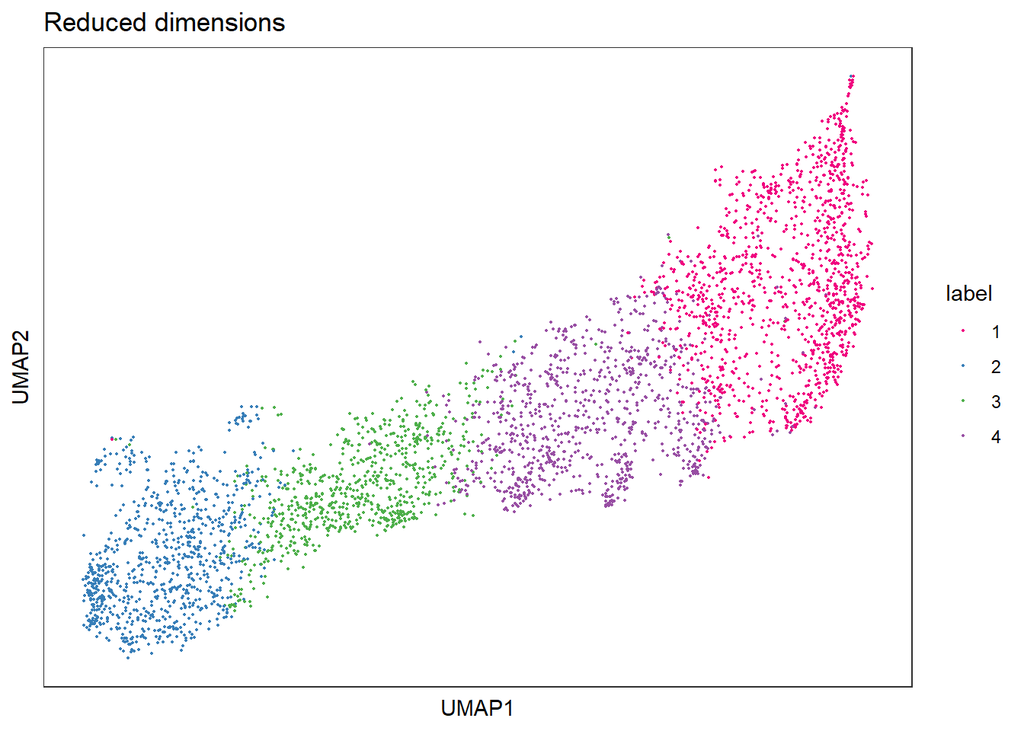

```r
# plot clusters in PCA reduced dimensions
plotDimRed(spe, type = "UMAP",
           annotate = "label", palette = "libd_layer_colors")
```

## Identifying Marker Genes

```r
# set gene names as row names for easier plotting
rownames(spe) <- rowData(spe)$symbols

# test for marker genes
markers <- findMarkers(spe, test = "binom", direction = "up")

# returns a list with one DataFrame per cluster
markers
```

```
## List of length 4
## names(4): 1 2 3 4
```

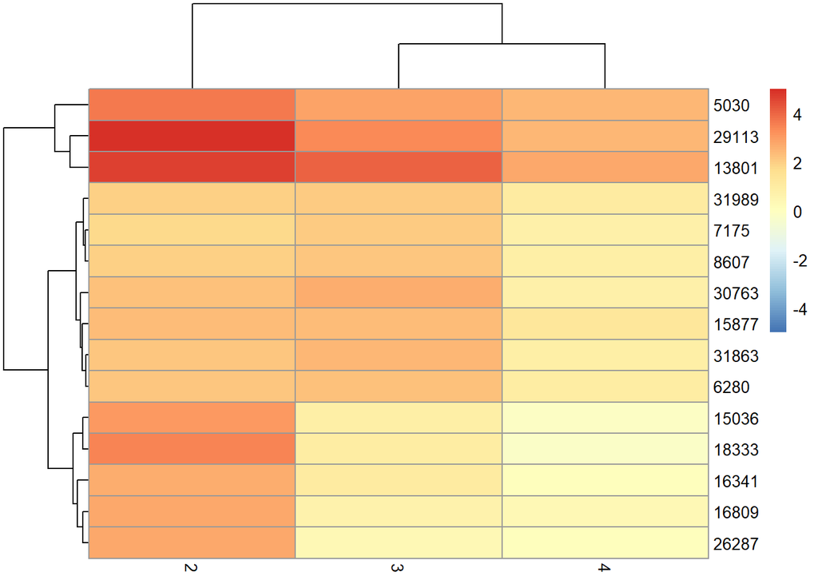

```r
# plot log-fold changes for one cluster over all other clusters
# selecting cluster 1

library(pheatmap)
interesting <- markers[[1]]
best_set <- interesting[interesting$Top <= 5, ]
logFCs <- getMarkerEffects(best_set)

pheatmap(logFCs, breaks = seq(-5, 5, length.out = 101))
```